# intent_dictionary

Will Schrepferman

4/30/2021

Here is the raw dictionary of INTENT terms we looked for; for reference, terms were stemmed and lemmatized so that variants of the same term or phrase could be considered as one. Additionally, I removed stop words from all terms (common, non-substantive words) for ease of analysis with the full corpus.

```r
dictionary_original$id <- seq.int(nrow(dictionary_original))
dictionary_stemmed$id <- seq.int(nrow(dictionary_stemmed))


joined_dictionary <- full_join(dictionary_original, dictionary_stemmed, by = "id") %>%
  select(word, value) %>%
  gt() %>%
  tab_header(title = "Original versus Stemmed Dictionary Terms") %>%
  cols_label(word = "Original Term", value = "Stemmed Term")

joined_dictionary
```

Original versus Stemmed Dictionary Terms

| Original Term | Stemmed Term |
| --- | --- |
| intent | intent |
| motivation | motiv |
| purpose | purpos |
| bias | bia |
| animus | animu |
| desire | desir |
| disgust | disgust |
| categorization | categor |
| classification | classif |
| disapproval | disapprov |

## Full Dictionary over Time

First, I did just a raw count of the dictionary occurring as a set over time:

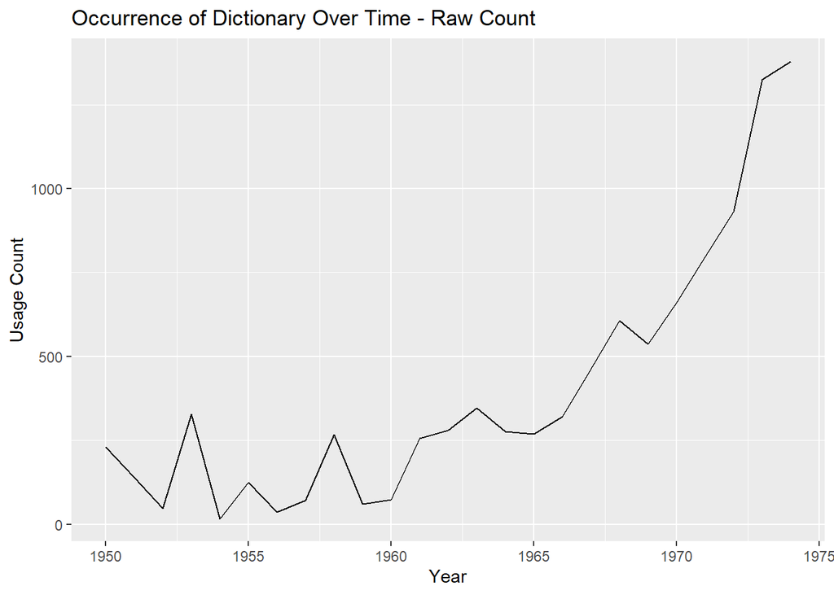

```r
dictionary_occurrences_overall_time_series <- dictionary_occurrences %>%
  group_by(year) %>%
  summarise(count = n()) %>%
  ggplot(aes(x = year, y = count)) +
  geom_line() +
  labs(title = "Occurrence of Dictionary Over Time - Raw Count", x = "Year", y = "Usage Count")
dictionary_occurrences_overall_time_series
```

However, this raw count doesn’t paint the full picture, so I also did a *relative* count of terms. This is simply the percentage of terms in a given year that were terms from our dictionary.

```r
dictionary_occurrences_raw <- dictionary_occurrences %>%
  group_by(year) %>%
  summarise(count_dict = n())
overall_occurrences <- corpus_relevant %>%
  unnest_tokens(word, clean_text) %>%
  group_by(year) %>%
  summarise(count_ovr = n())
```

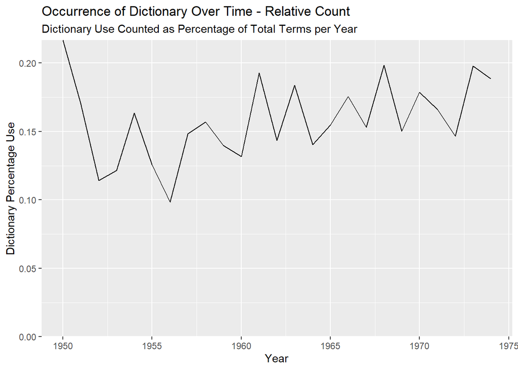

```r
dictionary_occurrences_relative_time_series <- dictionary_occurrences_raw %>%
  right_join(overall_occurrences, by = "year") %>%
  mutate(rel_occurrences = 100*(count_dict/count_ovr)) %>%
  ggplot(aes(x = year, y = rel_occurrences)) +
  geom_line() +
  scale_y_continuous(expand = c(0, 0), limits = c(0, NA)) +
  labs(title = "Occurrence of Dictionary Over Time - Relative Count", subtitle = "Dictionary Use Counted as Percentage of Total Terms per Year", x = "Year", y = "Dictionary Percentage Use")

dictionary_occurrences_relative_time_series
```

## Overall Rankings

Next, I ran some quick rankings. First up is a ranking of terms by overall counts:

```r
dictionary_occurrences %>%
  group_by(phrase) %>%
  summarise(count = n()) %>%
  arrange(-count) %>%
  gt() %>%
  tab_header(title = "Top Terms") %>%
  cols_label(phrase = "Term", count = "Total Uses of Dictionary Terms")
```

Top Terms

| Term | Total Uses of Dictionary Terms |
| --- | --- |
| purpos | 4743 |
| desir | 1440 |
| intent | 1369 |
| classif | 1181 |
| motiv | 677 |
| disapprov | 231 |
| bia | 102 |
| categor | 85 |
| animu | 10 |
| disgust | 6 |

Then, the top 50 cases with the highest dictionary term counts:

```r
dictionary_occurrences %>%
  select(slug, id) %>%
  group_by(id) %>%
  summarise(count = n(), slug = max(slug)) %>%
  select(slug, id, count) %>%
  arrange(-count) %>%
  head(50) %>%
  gt() %>%
  tab_header(title = "Top Cases - By Raw Counts") %>%
  cols_label(id = "Case ID", slug = "Case", count = "Total Uses of Dictionary Terms")
```

Top Cases - By Raw Counts

| Case | Case ID | Total Uses of Dictionary Terms |
| --- | --- | --- |
| united-states-v-ei-du-pont-de-nemours-co | 2168878 | 179 |
| telex-corp-v-international-business-machines-corp | 256638 | 136 |
| san-antonio-independent-school-dist-v-rodriguez | 1007608 | 134 |
| united-states-v-central-motor-lines-inc | 2049214 | 130 |
| united-states-v-hk-porter-company | 1811078 | 118 |
| united-states-v-morgan | 2483306 | 112 |
| healing-v-jones | 1788328 | 108 |
| hanson-v-birmingham | 244771 | 104 |
| hobson-v-hansen | 1375126 | 100 |
| shapiro-v-thompson | 239720 | 91 |
| united-states-v-state-of-mississippi | 2252470 | 86 |
| dobbins-v-local-212-international-bro-of-elec-wkrs | 2047902 | 85 |
| united-states-v-norcome | 2521344 | 83 |
| hart-v-community-sch-bd-of-brooklyn-ny-sch-d-21 | 2095596 | 77 |
| national-assn-for-advance-of-colored-people-v-patty | 2519558 | 77 |
| belcher-v-birmingham-trust-national-bank | 1856832 | 73 |
| united-states-v-state-of-louisiana | 2521051 | 72 |
| higgins-v-board-of-education-grand-rapids-mich | 1608906 | 71 |
| abington-school-dist-v-schempp | 10665 | 67 |
| united-states-v-school-dist-of-omaha-state-of-neb | 1161645 | 66 |
| oliver-v-kalamazoo-board-of-education | 1377126 | 64 |
| lewis-v-city-of-grand-rapids-michigan | 1854925 | 62 |
| stamps-v-detroit-edison-co | 142130 | 61 |
| pan-american-world-airways-inc-v-aetna-cas-sur-co | 1720639 | 61 |
| morales-v-turman | 2095600 | 61 |
| evans-v-abney | 120410 | 60 |
| keyes-v-school-district-number-one-denver-colorado | 1819381 | 58 |
| in-re-flying-w-airways-inc | 1618155 | 57 |
| oregon-v-mitchell | 1507065 | 55 |
| granader-v-public-bank | 1141453 | 54 |
| green-v-connally | 2521322 | 54 |
| poindexter-v-louisiana-financial-assistance-commission | 2466943 | 51 |
| mcgautha-v-california | 1050784 | 49 |
| consumers-power-company-v-united-states | 1795954 | 48 |
| el-paso-county-water-imp-dist-no-1-v-city-of-el-paso | 1809998 | 48 |
| commonwealth-of-pennsylvania-v-brown | 1778538 | 46 |
| rhem-v-malcolm | 1958359 | 46 |
| meek-v-pittenger | 2252900 | 46 |
| lemon-v-kurtzman | 2458148 | 46 |
| milliken-v-bradley | 1119562 | 45 |
| trinity-episcopal-school-corporation-v-romney | 1261179 | 45 |
| beer-v-united-states | 2252896 | 45 |
| mcglotten-v-connally | 2037423 | 44 |
| wright-v-council-of-emporia | 239744 | 42 |
| baker-v-carr | 1694900 | 42 |
| united-states-v-tillman | 2521355 | 42 |
| associated-gen-contractors-of-mass-inc-v-altshuler | 1175806 | 41 |
| geer-v-birmingham | 1781172 | 41 |
| united-states-v-united-states-cartridge-co | 2134677 | 41 |
| in-re-west-coast-cabinet-works | 1377922 | 40 |

Then, the top 50 most frequent cases in terms of dictionary richness (percentage of dictionary words in its overall word count):

```r
dictionary_cases <- dictionary_occurrences %>%
  group_by(id) %>%
  summarise(count = n(), slug = max(slug)) %>%
  select(slug, id, count)
overall_cases <- corpus_relevant %>%
  select(slug, id, doc_length_post_clean)

case_richness <- dictionary_cases %>%
  right_join(overall_cases, by = "id") %>%
  mutate(slug = slug.x) %>%
  mutate(richness = 100*(count/doc_length_post_clean)) %>%
  arrange(-richness) %>%
  select(slug, id, richness) %>%
  head(50) %>%
  gt() %>%
  tab_header(title = "Top Cases - By Dictionary Richness") %>%
  cols_label(slug = "Case", id = "Case ID", richness = "Percent of Dictionary Terms in Case")


case_richness
```

Top Cases - By Dictionary Richness

| Case | Case ID | Percent of Dictionary Terms in Case |
| --- | --- | --- |
| bush-v-orleans-parish-school-board | 1702411 | 1.5254237 |
| metropolitan-hous-dev-corp-v-village-of-arlington-hts | 2521468 | 0.8482564 |
| broussard-v-schlumberger-well-services | 2263391 | 0.8375635 |
| united-states-v-boone | 1605846 | 0.8308895 |
| evans-v-abney | 120410 | 0.8244023 |
| gautreaux-v-chicago-housing-authority | 1018471 | 0.8097166 |
| united-states-v-central-motor-lines-inc | 2049214 | 0.6915261 |
| united-states-v-tillman | 2521355 | 0.6822612 |
| mitchell-v-boslow | 2025308 | 0.6622517 |
| robertson-v-city-of-salem | 1010191 | 0.6568516 |
| webb-v-board-of-education-of-city-of-chicago | 2114341 | 0.6189821 |
| hobson-v-hansen | 1033803 | 0.6164685 |
| hutchison-v-lake-oswego-school-district | 2252749 | 0.6097561 |
| united-states-v-norcome | 2521344 | 0.6062377 |
| hanson-v-birmingham | 244771 | 0.6011908 |
| evans-v-buchanan | 1632780 | 0.5566600 |
| weaver-v-kelton | 2025090 | 0.5529226 |
| soria-v-oxnard-school-district-board-of-trustees | 2155167 | 0.5167959 |
| griggs-v-cook | 1813377 | 0.4968619 |
| shapiro-v-thompson | 239720 | 0.4961021 |
| griggs-v-duke-power-company | 1979435 | 0.4865104 |
| mcglotten-v-connally | 2037423 | 0.4821918 |
| poindexter-v-louisiana-financial-assistance-commission | 1034105 | 0.4812834 |
| poe-v-werner | 286135 | 0.4799192 |
| taylor-v-coahoma-county-school-district | 1461428 | 0.4725898 |
| franklin-v-quitman-county-board-of-education | 1215094 | 0.4703511 |
| norwalk-core-v-norwalk-board-of-education | 1740722 | 0.4621682 |
| gautreaux-v-romney | 1191418 | 0.4618938 |
| united-states-v-bossier-parish-school-board | 1393988 | 0.4552846 |
| wright-v-council-of-emporia | 239744 | 0.4320099 |
| ramos-v-united-states-civil-service-commission | 1034955 | 0.4283138 |
| linker-v-unified-school-district-259-wichita-kansas | 2150002 | 0.4131309 |
| brown-v-board-of-education-of-city-of-chicago | 2155146 | 0.4131054 |
| parish-v-national-collegiate-athletic-association | 1124597 | 0.4110613 |
| adderley-v-florida | 122747 | 0.4088586 |
| thompson-v-housing-authority-of-city-of-miami-fla | 1841694 | 0.4060325 |
| sisters-of-prov-of-st-mary-of-woods-v-city-of-evanston | 1334066 | 0.4020909 |
| topic-v-circle-realty-company | 2213658 | 0.3966287 |
| crenshaw-county-private-school-foundation-v-connally | 1279900 | 0.3911343 |
| wetzel-v-liberty-mutual-insurance-company | 1388936 | 0.3907075 |
| swann-v-charlotte-mecklenburg-board-of-education | 2225143 | 0.3896564 |
| gottlieb-v-schaffer | 1623462 | 0.3870442 |
| alabama-naacp-state-conference-of-branches-v-wallace | 1374968 | 0.3846154 |
| guillory-v-administrators-of-tulane-university-of-la | 2105708 | 0.3820086 |
| acevedo-v-nassau-county-new-york | 2133500 | 0.3769521 |
| ochoa-v-monsanto-company | 1334291 | 0.3711201 |
| stone-v-egeler | 2213439 | 0.3671072 |
| chester-v-kinnamon | 1025248 | 0.3618818 |
| macias-v-finch | 2468793 | 0.3539493 |
| cox-v-allied-chemical-corp-local-216-int-u-of-op-eng | 294491 | 0.3530210 |

Next, the top 50 courts with the highest dictionary term counts:

```r
dictionary_occurrences %>%
  group_by(court) %>%
  summarise(count = n()) %>%
  arrange(-count) %>%
  head(50) %>%
  gt() %>%
  tab_header(title = "Top Courts Using Dictionary Terms - By Raw Counts") %>%
  cols_label(court = "Court", count = "Total Uses of Dictionary Terms")
```

Top Courts Using Dictionary Terms - By Raw Counts

| Court | Total Uses of Dictionary Terms |
| --- | --- |
| scotus | 1189 |
| dcd | 581 |
| nysd | 575 |
| laed | 438 |
| vaed | 358 |
| ilnd | 338 |
| paed | 277 |
| miwd | 256 |
| alnd | 249 |
| ncwd | 245 |
| ded | 244 |
| mied | 240 |
| almd | 232 |
| mdd | 207 |
| txsd | 192 |
| pawd | 181 |
| mssd | 167 |
| nyed | 160 |
| ared | 155 |
| iand | 145 |
| oknd | 136 |
| txwd | 133 |
| ohsd | 132 |
| cod | 131 |
| txed | 129 |
| azd | 113 |
| ksd | 105 |
| cand | 102 |
| casd | 102 |
| vawd | 102 |
| moed | 100 |
| ncmd | 96 |
| ned | 90 |
| gand | 86 |
| ctd | 84 |
| ohnd | 81 |
| southcarolinaed | 81 |
| gamd | 78 |
| wiwd | 76 |
| tnmd | 74 |
| mad | 72 |
| scd | 72 |
| tned | 70 |
| innd | 66 |
| nced | 66 |
| msnd | 63 |
| ord | 63 |
| cacd | 61 |
| alsd | 54 |
| flmd | 53 |

And the top 50 courts in terms of dictionary richness (percentage of dictionary words across all of a court’s text):

```r
dictionary_courts <- dictionary_occurrences %>%
  group_by(court) %>%
  summarise(count_dict = n())
overall_courts <- corpus_relevant %>%
  select(court, doc_length_post_clean) %>%
  group_by(court) %>%
  summarise(count = sum(doc_length_post_clean))
court_richness <- dictionary_courts %>%
  right_join(overall_courts, by = "court") %>%
  mutate(richness = 100*(count_dict/count)) %>%
  arrange(-richness) %>%
  select(court, richness) %>%
  head(50)

court_richness  %>%
  gt() %>%
  tab_header(title = "Top Courts - By Dictionary Richness") %>%
  cols_label(court = "Court", richness = "Percent of Dictionary Terms for all Cases")
```

Top Courts - By Dictionary Richness

| Court | Percent of Dictionary Terms for all Cases |
| --- | --- |
| nmd | 0.4794348 |
| prd | 0.4283138 |
| pamd | 0.3843879 |
| nvd | 0.3529948 |
| ord | 0.3175723 |
| iand | 0.3148957 |
| lamd | 0.2698215 |
| azd | 0.2532213 |
| ohsd | 0.2335994 |
| innd | 0.2327796 |
| caed | 0.2309913 |
| miwd | 0.2191274 |
| flnd | 0.2139566 |
| waed | 0.2123706 |
| oknd | 0.2114099 |
| ohnd | 0.2107948 |
| ned | 0.2066732 |
| sdd | 0.2051282 |
| akd | 0.2034292 |
| dcd | 0.1977879 |
| ncwd | 0.1977210 |
| ctd | 0.1934949 |
| laed | 0.1915717 |
| ksd | 0.1914207 |
| alsd | 0.1869741 |
| pawd | 0.1802322 |
| moed | 0.1778980 |
| scd | 0.1761640 |
| mied | 0.1751799 |
| utd | 0.1747997 |
| mdd | 0.1746585 |
| mad | 0.1733353 |
| scotus | 0.1725902 |
| gamd | 0.1677419 |
| alnd | 0.1675481 |
| wiwd | 0.1659787 |
| njd | 0.1657740 |
| nced | 0.1657667 |
| ncmd | 0.1652864 |
| rid | 0.1649659 |
| nyed | 0.1636260 |
| mssd | 0.1627014 |
| oked | 0.1589651 |
| southcarolinaed | 0.1583392 |
| vaed | 0.1564877 |
| hid | 0.1549770 |
| ded | 0.1494100 |
| cod | 0.1460277 |
| txed | 0.1439122 |
| ared | 0.1429810 |

Additionally, here are the 5 richest individual cases from the 25 richest courts. It may be worthwhile for further analysis to include a filter of ‘at least X cases must be present in a court for it to be considered.’

```r
case_richness_overall <- dictionary_cases %>%
  right_join(corpus_relevant, by = "id") %>%
  mutate(slug = slug.x) %>%
  mutate(richness = 100*(count/doc_length_post_clean)) %>%
  select(id, slug, count, doc_length_post_clean, richness, year, court, judges, federal_cite, resource_uri) %>%
  head(690)

richest_courts <-court_richness %>%
  select(court)

# for some reason, this for loop doesn't work. going for a manual solution

for(i in 1:25){
  court_in_question <- richest_courts[[1]][i]

  case_richness_in_question <- case_richness_overall %>%
    filter(court == court_in_question) %>%
    select(id, slug, year, richness) %>%
    arrange(-richness) %>%
    head(5) %>%
    gt() %>%
    tab_header(title = paste("Top Cases - ", court_in_question)) %>%
    cols_label(id = "ID", slug = "slug", year = "Year", richness = "Richness")

  case_richness_in_question
}

court_in_question <- richest_courts[[1]][1]
case_richness_in_question <- case_richness_overall %>%
    filter(court == court_in_question) %>%
    select(id, slug, year, richness) %>%
    arrange(-richness) %>%
    head(5) %>%
    gt() %>%
    tab_header(title = paste("Top Cases - ", court_in_question)) %>%
    cols_label(id = "ID", slug = "slug", year = "Year", richness = "Richness")
case_richness_in_question
```

Top Cases - nmd

| ID | slug | Year | Richness |
| --- | --- | --- | --- |
| 1605846 | united-states-v-boone | 1972 | 0.8308895 |
| 292946 | serna-v-portales-municipal-schools | 1972 | 0.1043297 |

```r
court_in_question <- richest_courts[[1]][2]
case_richness_in_question <- case_richness_overall %>%
    filter(court == court_in_question) %>%
    select(id, slug, year, richness) %>%
    arrange(-richness) %>%
    head(5) %>%
    gt() %>%
    tab_header(title = paste("Top Cases - ", court_in_question)) %>%
    cols_label(id = "ID", slug = "slug", year = "Year", richness = "Richness")
case_richness_in_question
```

Top Cases - prd

| ID | slug | Year | Richness |
| --- | --- | --- | --- |
| 1034955 | ramos-v-united-states-civil-service-commission | 1974 | 0.4283138 |

```r
court_in_question <- richest_courts[[1]][3]
case_richness_in_question <- case_richness_overall %>%
    filter(court == court_in_question) %>%
    select(id, slug, year, richness) %>%
    arrange(-richness) %>%
    head(5) %>%
    gt() %>%
    tab_header(title = paste("Top Cases - ", court_in_question)) %>%
    cols_label(id = "ID", slug = "slug", year = "Year", richness = "Richness")
case_richness_in_question
```

Top Cases - pamd

| ID | slug | Year | Richness |
| --- | --- | --- | --- |
| 286135 | poe-v-werner | 1974 | 0.4799192 |
| 1492804 | young-v-coder | 1972 | 0.0448833 |

```r
court_in_question <- richest_courts[[1]][4]
case_richness_in_question <- case_richness_overall %>%
    filter(court == court_in_question) %>%
    select(id, slug, year, richness) %>%
    arrange(-richness) %>%
    head(5) %>%
    gt() %>%
    tab_header(title = paste("Top Cases - ", court_in_question)) %>%
    cols_label(id = "ID", slug = "slug", year = "Year", richness = "Richness")
case_richness_in_question
```

Top Cases - nvd

| ID | slug | Year | Richness |
| --- | --- | --- | --- |
| 1462151 | united-states-v-local-no-357-of-int-bro-of-elec-wkrs | 1973 | 0.3529948 |

```r
court_in_question <- richest_courts[[1]][5]
case_richness_in_question <- case_richness_overall %>%
    filter(court == court_in_question) %>%
    select(id, slug, year, richness) %>%
    arrange(-richness) %>%
    head(5) %>%
    gt() %>%
    tab_header(title = paste("Top Cases - ", court_in_question)) %>%
    cols_label(id = "ID", slug = "slug", year = "Year", richness = "Richness")
case_richness_in_question
```

Top Cases - ord

| ID | slug | Year | Richness |
| --- | --- | --- | --- |
| 1010191 | robertson-v-city-of-salem | 1961 | 0.65685164 |
| 2252749 | hutchison-v-lake-oswego-school-district | 1974 | 0.60975610 |
| 1835880 | sohappy-v-smith | 1969 | 0.08152617 |
| 1923963 | rees-v-united-states | 1960 | 0.04244482 |
| 2544558 | NA | 1958 | NA |

```r
court_in_question <- richest_courts[[1]][6]
case_richness_in_question <- case_richness_overall %>%
    filter(court == court_in_question) %>%
    select(id, slug, year, richness) %>%
    arrange(-richness) %>%
    head(5) %>%
    gt() %>%
    tab_header(title = paste("Top Cases - ", court_in_question)) %>%
    cols_label(id = "ID", slug = "slug", year = "Year", richness = "Richness")
case_richness_in_question
```

Top Cases - iand

| ID | slug | Year | Richness |
| --- | --- | --- | --- |
| 244771 | hanson-v-birmingham | 1950 | 0.6011908 |
| 1781172 | geer-v-birmingham | 1950 | 0.1426186 |

```r
court_in_question <- richest_courts[[1]][7]
case_richness_in_question <- case_richness_overall %>%
    filter(court == court_in_question) %>%
    select(id, slug, year, richness) %>%
    arrange(-richness) %>%
    head(5) %>%
    gt() %>%
    tab_header(title = paste("Top Cases - ", court_in_question)) %>%
    cols_label(id = "ID", slug = "slug", year = "Year", richness = "Richness")
case_richness_in_question
```

Top Cases - lamd

| ID | slug | Year | Richness |
| --- | --- | --- | --- |
| 294491 | cox-v-allied-chemical-corp-local-216-int-u-of-op-eng | 1974 | 0.353021 |
| 1608424 | NA | 1973 | NA |

```r
court_in_question <- richest_courts[[1]][8]
case_richness_in_question <- case_richness_overall %>%
    filter(court == court_in_question) %>%
    select(id, slug, year, richness) %>%
    arrange(-richness) %>%
    head(5) %>%
    gt() %>%
    tab_header(title = paste("Top Cases - ", court_in_question)) %>%
    cols_label(id = "ID", slug = "slug", year = "Year", richness = "Richness")
case_richness_in_question
```

Top Cases - azd

| ID | slug | Year | Richness |
| --- | --- | --- | --- |
| 1788328 | healing-v-jones | 1962 | 0.2570816 |
| 1603335 | gonzales-v-sheely | 1951 | 0.1912046 |

```r
court_in_question <- richest_courts[[1]][9]
case_richness_in_question <- case_richness_overall %>%
    filter(court == court_in_question) %>%
    select(id, slug, year, richness) %>%
    arrange(-richness) %>%
    head(5) %>%
    gt() %>%
    tab_header(title = paste("Top Cases - ", court_in_question)) %>%
    cols_label(id = "ID", slug = "slug", year = "Year", richness = "Richness")
case_richness_in_question
```

Top Cases - ohsd

| ID | slug | Year | Richness |
| --- | --- | --- | --- |
| 2462823 | kosydar-v-wolman | 1972 | 0.28270171 |
| 2047902 | dobbins-v-local-212-international-bro-of-elec-wkrs | 1968 | 0.28026906 |
| 1132977 | newbern-v-lake-lorelei-inc | 1968 | 0.09068924 |
| 1803740 | deal-v-cincinnati-board-of-education | 1965 | 0.06177606 |

```r
court_in_question <- richest_courts[[1]][10]
case_richness_in_question <- case_richness_overall %>%
    filter(court == court_in_question) %>%
    select(id, slug, year, richness) %>%
    arrange(-richness) %>%
    head(5) %>%
    gt() %>%
    tab_header(title = paste("Top Cases - ", court_in_question)) %>%
    cols_label(id = "ID", slug = "slug", year = "Year", richness = "Richness")
case_richness_in_question
```

Top Cases - innd

| ID | slug | Year | Richness |
| --- | --- | --- | --- |
| 1718481 | barrick-realty-incorporated-v-city-of-gary-indiana | 1973 | 0.2897069 |
| 2137569 | bell-v-school-city-of-gary-indiana | 1963 | 0.2618075 |
| 1039929 | bright-v-isenbarger | 1970 | 0.1914334 |
| 1006734 | nelson-v-heyne | 1973 | 0.1747488 |

```r
court_in_question <- richest_courts[[1]][11]
case_richness_in_question <- case_richness_overall %>%
    filter(court == court_in_question) %>%
    select(id, slug, year, richness) %>%
    arrange(-richness) %>%
    head(5) %>%
    gt() %>%
    tab_header(title = paste("Top Cases - ", court_in_question)) %>%
    cols_label(id = "ID", slug = "slug", year = "Year", richness = "Richness")
case_richness_in_question
```

Top Cases - caed

| ID | slug | Year | Richness |
| --- | --- | --- | --- |
| 2462137 | salyer-land-co-v-tulare-lake-basin-water-storage-dist | 1972 | 0.2309913 |

```r
court_in_question <- richest_courts[[1]][12]
case_richness_in_question <- case_richness_overall %>%
    filter(court == court_in_question) %>%
    select(id, slug, year, richness) %>%
    arrange(-richness) %>%
    head(5) %>%
    gt() %>%
    tab_header(title = paste("Top Cases - ", court_in_question)) %>%
    cols_label(id = "ID", slug = "slug", year = "Year", richness = "Richness")
case_richness_in_question
```

Top Cases - miwd

| ID | slug | Year | Richness |
| --- | --- | --- | --- |
| 2213439 | stone-v-egeler | 1973 | 0.3671072 |
| 1810705 | ranjel-v-city-of-lansing | 1969 | 0.2683928 |
| 1608906 | higgins-v-board-of-education-grand-rapids-mich | 1973 | 0.2460323 |
| 1854925 | lewis-v-city-of-grand-rapids-michigan | 1963 | 0.2270064 |
| 1020914 | reed-v-van-hoven | 1965 | 0.1990230 |

```r
court_in_question <- richest_courts[[1]][13]
case_richness_in_question <- case_richness_overall %>%
    filter(court == court_in_question) %>%
    select(id, slug, year, richness) %>%
    arrange(-richness) %>%
    head(5) %>%
    gt() %>%
    tab_header(title = paste("Top Cases - ", court_in_question)) %>%
    cols_label(id = "ID", slug = "slug", year = "Year", richness = "Richness")
case_richness_in_question
```

Top Cases - flnd

| ID | slug | Year | Richness |
| --- | --- | --- | --- |
| 1175850 | augustus-v-school-board-of-escambia-county | 1973 | 0.32751092 |
| 1336799 | augustus-v-board-of-public-instr-of-escambia-co-fla | 1960 | 0.04145937 |

```r
court_in_question <- richest_courts[[1]][14]
case_richness_in_question <- case_richness_overall %>%
    filter(court == court_in_question) %>%
    select(id, slug, year, richness) %>%
    arrange(-richness) %>%
    head(5) %>%
    gt() %>%
    tab_header(title = paste("Top Cases - ", court_in_question)) %>%
    cols_label(id = "ID", slug = "slug", year = "Year", richness = "Richness")
case_richness_in_question
```

Top Cases - waed

| ID | slug | Year | Richness |
| --- | --- | --- | --- |
| 1803646 | simmons-v-eagle-seelatsee | 1965 | 0.2123706 |

```r
court_in_question <- richest_courts[[1]][15]
case_richness_in_question <- case_richness_overall %>%
    filter(court == court_in_question) %>%
    select(id, slug, year, richness) %>%
    arrange(-richness) %>%
    head(5) %>%
    gt() %>%
    tab_header(title = paste("Top Cases - ", court_in_question)) %>%
    cols_label(id = "ID", slug = "slug", year = "Year", richness = "Richness")
case_richness_in_question
```

Top Cases - oknd

| ID | slug | Year | Richness |
| --- | --- | --- | --- |
| 256638 | telex-corp-v-international-business-machines-corp | 1973 | 0.2114099 |

```r
court_in_question <- richest_courts[[1]][16]
case_richness_in_question <- case_richness_overall %>%
    filter(court == court_in_question) %>%
    select(id, slug, year, richness) %>%
    arrange(-richness) %>%
    head(5) %>%
    gt() %>%
    tab_header(title = paste("Top Cases - ", court_in_question)) %>%
    cols_label(id = "ID", slug = "slug", year = "Year", richness = "Richness")
case_richness_in_question
```

Top Cases - ohnd

| ID | slug | Year | Richness |
| --- | --- | --- | --- |
| 2107792 | smith-v-city-of-east-cleveland | 1973 | 0.2745367 |
| 1018347 | banks-v-perk | 1972 | 0.2629734 |
| 2252546 | lynch-v-kenston-school-district-board-of-education | 1964 | 0.2338009 |
| 2003094 | oliphant-v-brotherhood-of-locomotive-fire-eng | 1957 | 0.2313744 |
| 1019703 | joseph-skillken-and-company-v-city-of-toledo | 1974 | 0.1764914 |

```r
court_in_question <- richest_courts[[1]][17]
case_richness_in_question <- case_richness_overall %>%
    filter(court == court_in_question) %>%
    select(id, slug, year, richness) %>%
    arrange(-richness) %>%
    head(5) %>%
    gt() %>%
    tab_header(title = paste("Top Cases - ", court_in_question)) %>%
    cols_label(id = "ID", slug = "slug", year = "Year", richness = "Richness")
case_richness_in_question
```

Top Cases - ned

| ID | slug | Year | Richness |
| --- | --- | --- | --- |
| 1161645 | united-states-v-school-dist-of-omaha-state-of-neb | 1974 | 0.2810544 |
| 2210074 | mcdonnell-v-wolff | 1972 | 0.1228275 |
| 1008720 | mcclelland-v-sigler | 1971 | 0.1057921 |

```r
court_in_question <- richest_courts[[1]][18]
case_richness_in_question <- case_richness_overall %>%
    filter(court == court_in_question) %>%
    select(id, slug, year, richness) %>%
    arrange(-richness) %>%
    head(5) %>%
    gt() %>%
    tab_header(title = paste("Top Cases - ", court_in_question)) %>%
    cols_label(id = "ID", slug = "slug", year = "Year", richness = "Richness")
case_richness_in_question
```

Top Cases - sdd

| ID | slug | Year | Richness |
| --- | --- | --- | --- |
| 2107375 | ellingson-v-sears-roebuck-company | 1973 | 0.2051282 |

```r
court_in_question <- richest_courts[[1]][19]
case_richness_in_question <- case_richness_overall %>%
    filter(court == court_in_question) %>%
    select(id, slug, year, richness) %>%
    arrange(-richness) %>%
    head(5) %>%
    gt() %>%
    tab_header(title = paste("Top Cases - ", court_in_question)) %>%
    cols_label(id = "ID", slug = "slug", year = "Year", richness = "Richness")
case_richness_in_question
```

Top Cases - akd

| ID | slug | Year | Richness |
| --- | --- | --- | --- |
| 2177085 | united-states-v-booth | 1958 | 0.2034292 |

```r
court_in_question <- richest_courts[[1]][20]
case_richness_in_question <- case_richness_overall %>%
    filter(court == court_in_question) %>%
    select(id, slug, year, richness) %>%
    arrange(-richness) %>%
    head(5) %>%
    gt() %>%
    tab_header(title = paste("Top Cases - ", court_in_question)) %>%
    cols_label(id = "ID", slug = "slug", year = "Year", richness = "Richness")
case_richness_in_question
```

Top Cases - dcd

| ID | slug | Year | Richness |
| --- | --- | --- | --- |
| 2521355 | united-states-v-tillman | 1974 | 0.6822612 |
| 1033803 | hobson-v-hansen | 1970 | 0.6164685 |
| 2521344 | united-states-v-norcome | 1974 | 0.6062377 |
| 2037423 | mcglotten-v-connally | 1972 | 0.4821918 |
| 2521322 | green-v-connally | 1971 | 0.3452685 |

```r
court_in_question <- richest_courts[[1]][21]
case_richness_in_question <- case_richness_overall %>%
    filter(court == court_in_question) %>%
    select(id, slug, year, richness) %>%
    arrange(-richness) %>%
    head(5) %>%
    gt() %>%
    tab_header(title = paste("Top Cases - ", court_in_question)) %>%
    cols_label(id = "ID", slug = "slug", year = "Year", richness = "Richness")
case_richness_in_question
```

Top Cases - ncwd

| ID | slug | Year | Richness |
| --- | --- | --- | --- |
| 2049214 | united-states-v-central-motor-lines-inc | 1971 | 0.6915261 |
| 2225143 | swann-v-charlotte-mecklenburg-board-of-education | 1965 | 0.3896564 |
| 1035292 | swann-v-charlotte-mecklenburg-board-of-education | 1970 | 0.2921841 |
| 2463658 | grier-v-specialized-skills-inc | 1971 | 0.2074689 |
| 1261548 | chambers-v-hendersonville-city-board-of-education | 1965 | 0.2072539 |

```r
court_in_question <- richest_courts[[1]][22]
case_richness_in_question <- case_richness_overall %>%
    filter(court == court_in_question) %>%
    select(id, slug, year, richness) %>%
    arrange(-richness) %>%
    head(5) %>%
    gt() %>%
    tab_header(title = paste("Top Cases - ", court_in_question)) %>%
    cols_label(id = "ID", slug = "slug", year = "Year", richness = "Richness")
case_richness_in_question
```

Top Cases - ctd

| ID | slug | Year | Richness |
| --- | --- | --- | --- |
| 1740722 | norwalk-core-v-norwalk-board-of-education | 1969 | 0.4621682 |
| 1215856 | united-states-v-hegstrom | 1959 | 0.2795899 |
| 1481994 | norwalk-core-v-norwalk-board-of-education | 1968 | 0.2483855 |
| 294029 | cornelius-v-benevolent-protective-order-of-elks | 1974 | 0.1507219 |
| 1260916 | paka-v-manson | 1974 | 0.1133391 |

```r
court_in_question <- richest_courts[[1]][23]
case_richness_in_question <- case_richness_overall %>%
    filter(court == court_in_question) %>%
    select(id, slug, year, richness) %>%
    arrange(-richness) %>%
    head(5) %>%
    gt() %>%
    tab_header(title = paste("Top Cases - ", court_in_question)) %>%
    cols_label(id = "ID", slug = "slug", year = "Year", richness = "Richness")
case_richness_in_question
```

Top Cases - laed

| ID | slug | Year | Richness |
| --- | --- | --- | --- |
| 1702411 | bush-v-orleans-parish-school-board | 1958 | 1.5254237 |
| 1034105 | poindexter-v-louisiana-financial-assistance-commission | 1968 | 0.4812834 |
| 2105708 | guillory-v-administrators-of-tulane-university-of-la | 1962 | 0.3820086 |
| 1190947 | boyd-v-pointe-coupee-parish-school-board | 1971 | 0.3303965 |
| 1960564 | hicks-v-crown-zellerbach-corporation | 1970 | 0.3231266 |

```r
court_in_question <- richest_courts[[1]][24]
case_richness_in_question <- case_richness_overall %>%
    filter(court == court_in_question) %>%
    select(id, slug, year, richness) %>%
    arrange(-richness) %>%
    head(5) %>%
    gt() %>%
    tab_header(title = paste("Top Cases - ", court_in_question)) %>%
    cols_label(id = "ID", slug = "slug", year = "Year", richness = "Richness")
case_richness_in_question
```

Top Cases - ksd

| ID | slug | Year | Richness |
| --- | --- | --- | --- |
| 2150002 | linker-v-unified-school-district-259-wichita-kansas | 1972 | 0.41313086 |
| 1598231 | americans-united-for-sep-of-church-state-v-bubb | 1974 | 0.20066506 |
| 1280175 | united-states-v-wyandotte-county-kansas | 1972 | 0.18680562 |
| 2459007 | brown-v-board-of-education-of-topeka | 1951 | 0.08984726 |
| 2024929 | poindexter-v-woodson | 1973 | 0.07748935 |

```r
court_in_question <- richest_courts[[1]][25]
case_richness_in_question <- case_richness_overall %>%
    filter(court == court_in_question) %>%
    select(id, slug, year, richness) %>%
    arrange(-richness) %>%
    head(5) %>%
    gt() %>%
    tab_header(title = paste("Top Cases - ", court_in_question)) %>%
    cols_label(id = "ID", slug = "slug", year = "Year", richness = "Richness")
case_richness_in_question
```

Top Cases - alsd

| ID | slug | Year | Richness |
| --- | --- | --- | --- |
| 288910 | lake-v-lee | 1971 | 0.2112676 |
| 2491588 | allen-v-city-of-mobile | 1971 | 0.1927092 |
| 1019417 | united-states-v-clark | 1965 | 0.1725980 |

## Individual Term Analyses

And finally, here are graphs for each individual word - both raw and relative counts.

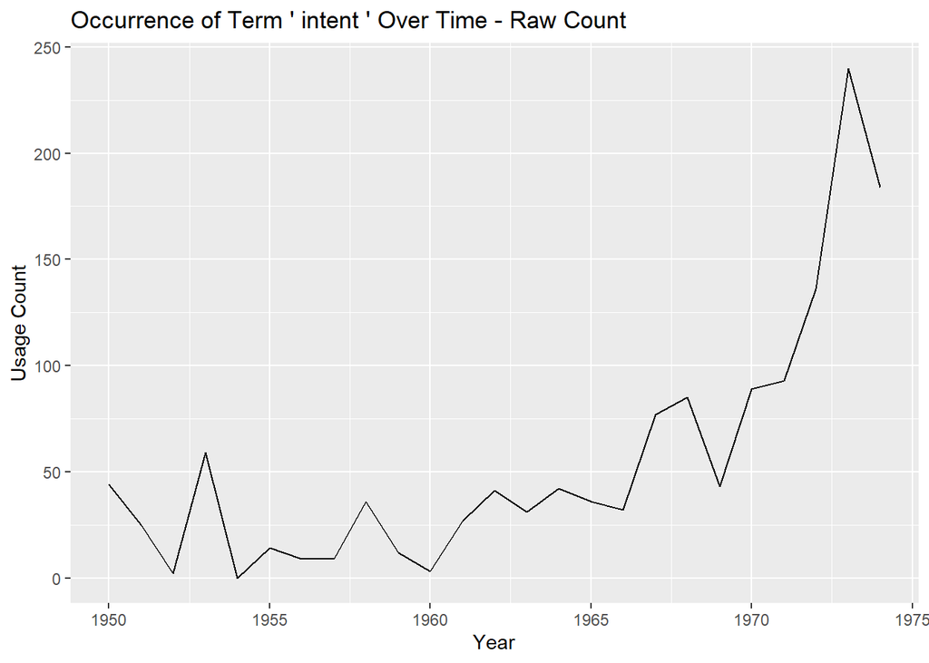

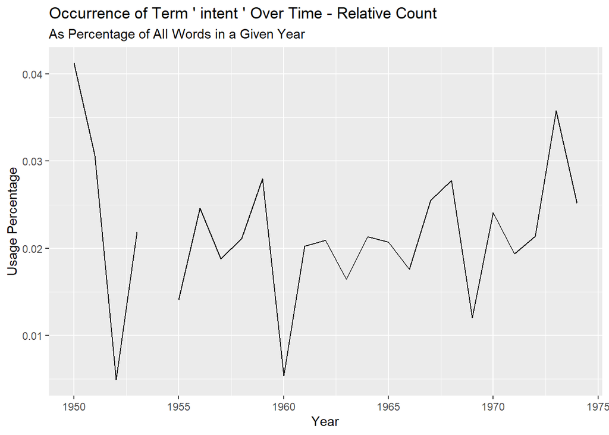

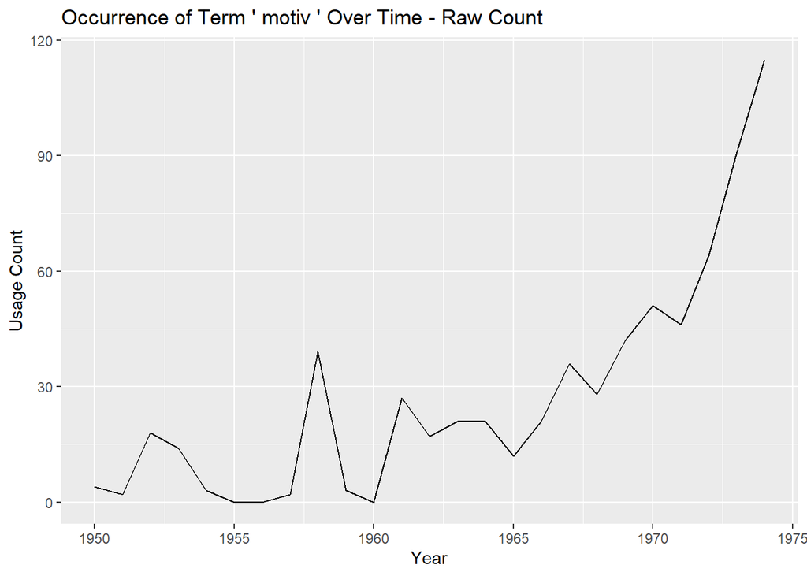

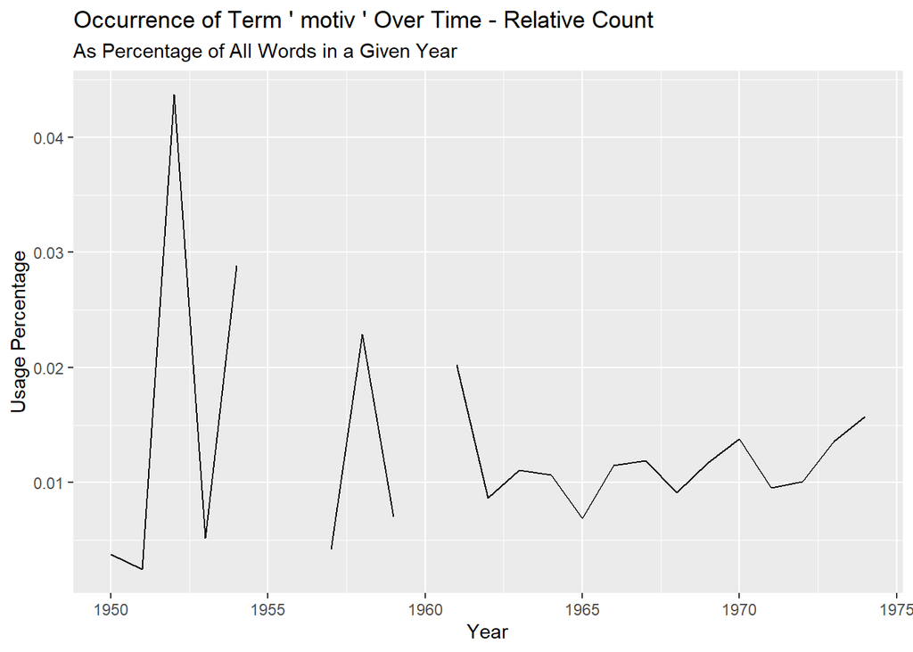

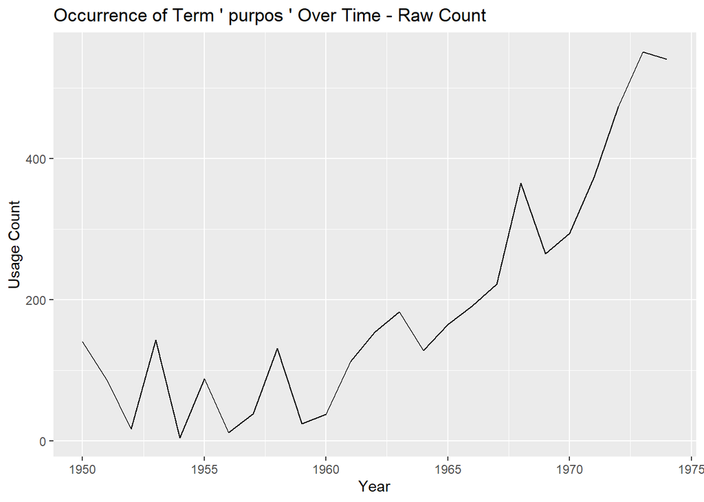

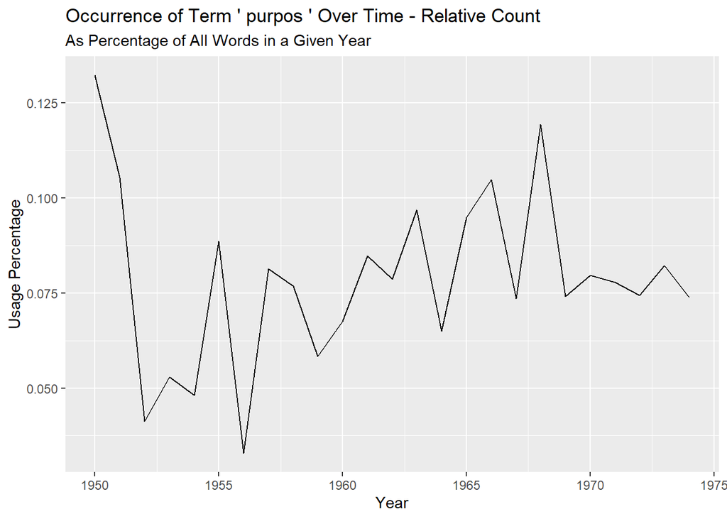

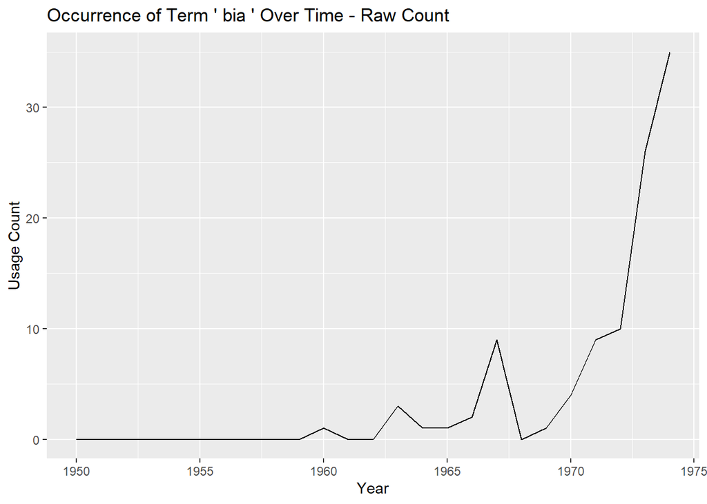

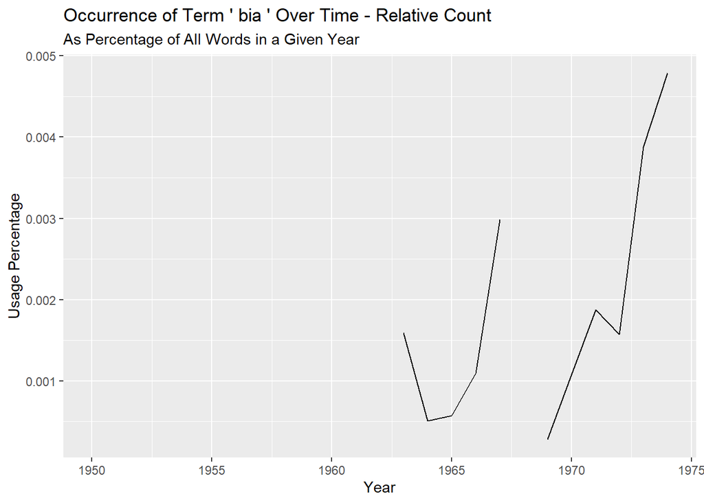

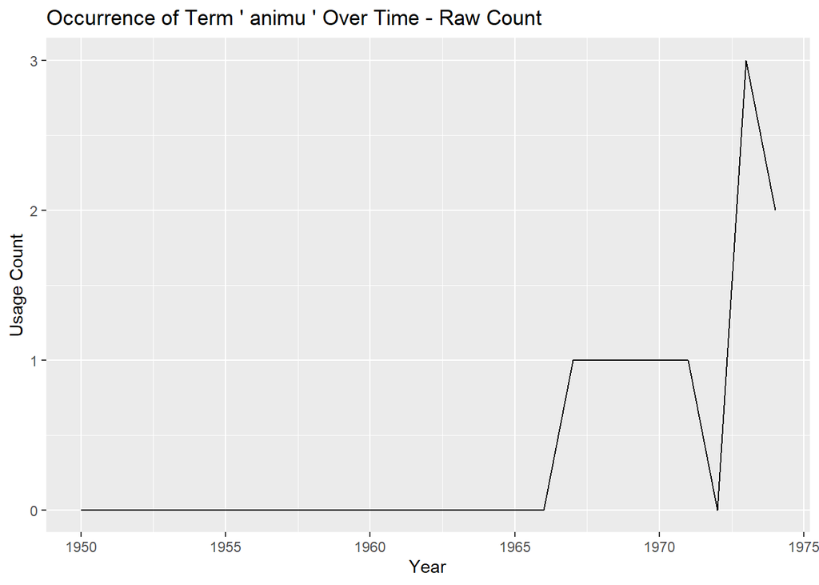

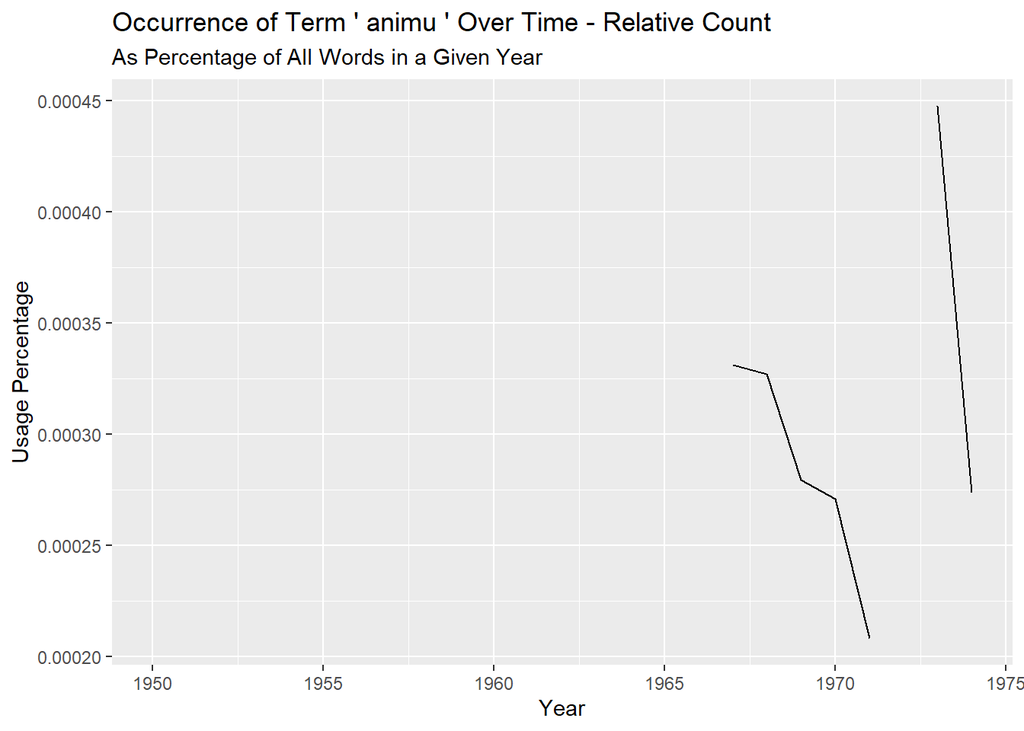

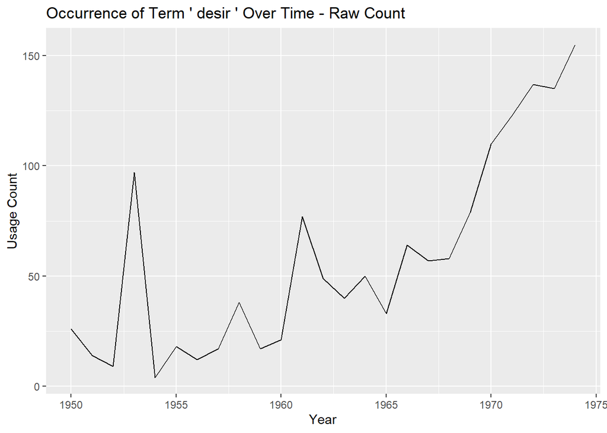

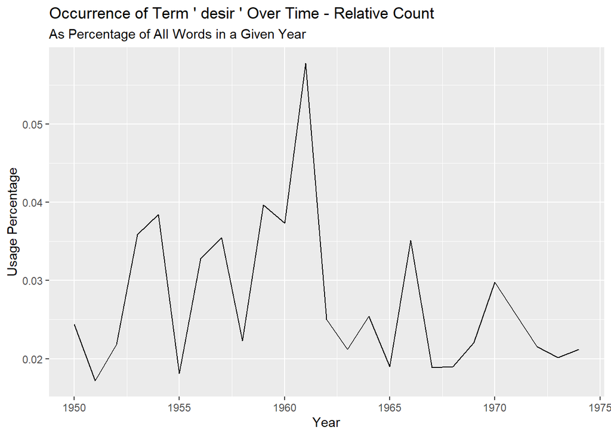

[8 more figures not shown]

```r
zeros_table <- tibble(year = (1950:1974))

raw_count_graph <- function(term){
  dictionary_occurences_filt <- dictionary_occurrences %>%
    filter(phrase == term)

  pull_sum <- dictionary_occurences_filt %>%
    group_by(year) %>%
    summarise(count = n()) %>%
    right_join(zeros_table, by = "year") %>%
    mutate(count = replace_na(count, 0)) %>%
    arrange(year)

  raw_plot <- pull_sum %>%
    ggplot(aes(x = year, y = count)) +
    geom_line() +
    labs(title = paste("Occurrence of Term '", term, "' Over Time - Raw Count"), x = "Year", y = "Usage Count")

  print(raw_plot)
}

rel_count_graph <- function(term){
  dictionary_occurences_filt <- dictionary_occurrences %>%
    filter(phrase == term)

  overall_occurrences <- corpus_relevant %>%
    unnest_tokens(word, clean_text) %>%
    group_by(year) %>%
    summarise(count_ovr = n())

  pull_sum <- dictionary_occurences_filt %>%
    group_by(year) %>%
    summarise(count = n()) %>%
    right_join(overall_occurrences, by = "year") %>%
    arrange(year) %>%
    mutate(percent_occurr = 100*(count/count_ovr)) %>%
    select(year, percent_occurr)


  raw_plot <- pull_sum %>%
    ggplot(aes(x = year, y = percent_occurr)) +
    geom_line() +
    labs(title = paste("Occurrence of Term '", term, "' Over Time - Relative Count"), subtitle = "As Percentage of All Words in a Given Year", x = "Year", y = "Usage Percentage")

  print(raw_plot)
}


for(i in 1:nrow(dictionary_stemmed)){
  raw_count_graph(dictionary_stemmed[[1]][i])
  rel_count_graph(dictionary_stemmed[[1]][i])
}
```